# STA 380 Homework 2

Henry Chang, Joseph Chin, Tiffany Sung, Jeffrey Fulkerson

August 17, 2018

# Problem 1: Flighs at ABIA

```r
library(RColorBrewer)
library(gplots)
#setup

# Read in Data
data_raw <- read.csv(url("https://raw.githubusercontent.com/jgscott/STA380/master/data/ABIA.csv"))
# Clean
# --Year is the same for every row
# --Only interested in flights originating from Austin, TX
drops <- c("Year")
data <- data_raw[ data_raw$Origin == "AUS", !(names(data_raw) %in% drops)]
rm(data_raw)
```

For the purpose of this project, We decide to narrow our analysis to flights departing from AUS only.

### EDA

**In the EDA process we are interested in how we can minimize delay.**

We believe that a delay longer than 45 minutes is significant to a business traveler; thus, we decide to analyze flights meeting this standard in Austin-Bergstrom International Airport in 2008.

```
##
##     1     2     3     4     5     6     7
## 16.34 14.36 12.39 15.18 17.35  9.50 14.88
##    Min. 1st Qu.  Median    Mean 3rd Qu.    Max.
##   46.00   58.00   78.00   96.13  116.00  328.00
```

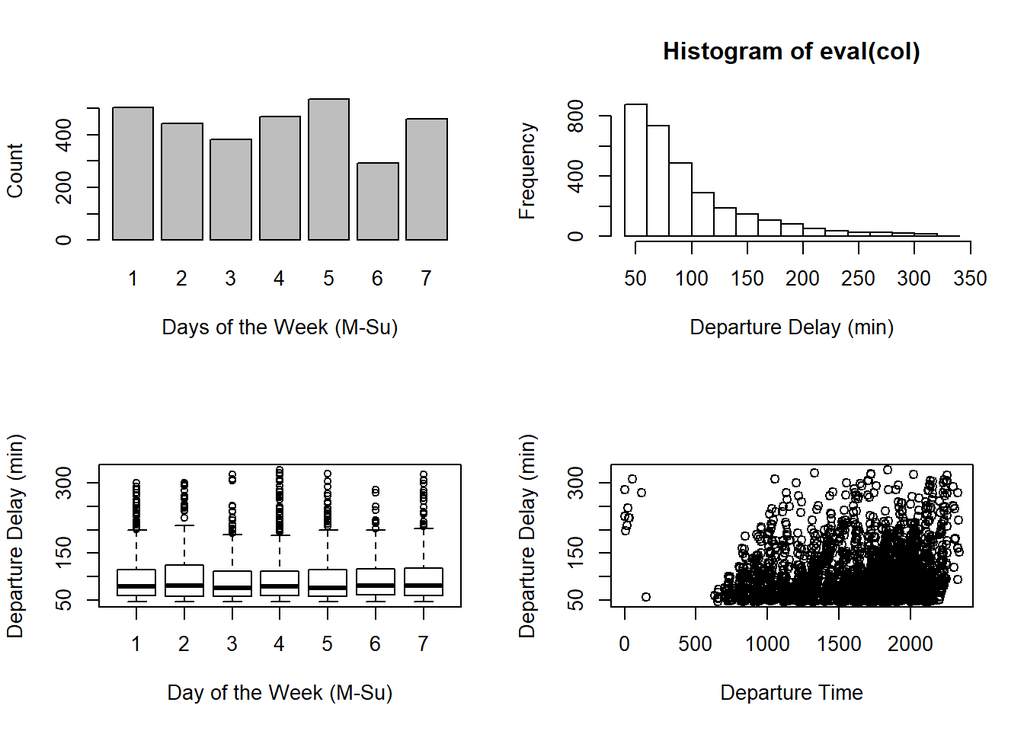

```r
# Plotting functions
plot_delays <- function(dcol, col, colName){
  ## This function plots delay variables
  # --Model
  threshold = 45
  delays <- data[eval(dcol) > threshold,]
  # --Clean Delays data of high outliers and NA
  delays <- delays[eval(col) < unname(quantile(eval(col), 0.99, na.rm = TRUE)),]
  delays <- delays[! is.na(eval(col)),]
  # --Display Results
  print(round(table(delays$DayOfWeek) / dim(delays)[1] * 100.0, 2))
  print(summary(eval(col)))
  par(mfrow=c(2,2))
  barplot(table(delays$DayOfWeek), xlab="Days of the Week (M-Su)", ylab="Count")
  hist(eval(col), xlab = colName)
  boxplot(eval(col) ~ delays$DayOfWeek, xlab = "Day of the Week (M-Su)" , ylab = colName)
  plot(delays$DepTime, eval(col), xlab = "Departure Time" , ylab = colName)
}
```

### Delay Heatmap

Given the summary above, we would like to create several delay heatmaps to help business travelers flying out of Austin minimize delay time by choosing the optimal time, day, and Airline combination.

We create heatmaps for the top 5 airlines with the most number of flights in AUS:

1. Southwest Airlines (WN)
2. American Airlines (AA)
3. Continental Airlines (CO)
4. Mesa Airlines (YV)
5. JetBlue Airways (B6)

```r
# CREATE A HEATMAP
# Create a Day of Week by Departure Time matrix of Average Delays (in minutes)
# for a particular airline
airlines <- c("WN", "AA", "CO", "YV", "B6")
carrierCodeLookup <- c("Southwest Airlines",
                       "American Airlines",
                       "Continental (UA)",
                       "Mesa Airlines",
                       "JetBlue")

airlineHeatMap <- function(cc, airlineName, timeIntervalInMinutes, thresholdInMinutes){

  # Setup
  timeInterval_converted <- timeIntervalInMinutes*(5.0/3.0) # Convertion from base 60 (time) to base 100 (0-2400)
  threshold <- thresholdInMinutes*(5.0/3.0) # How many minutes late are we counting, converted to base 100
  numRows <- 2400/(timeInterval_converted)
  values <- c()

  # Get Dataframe of just Carrier Code cc
  cc_data <- data[data$UniqueCarrier == cc, c("DayOfWeek", "DepTime", "DepDelay")] # TODO Limit this to just the necessary list of columns

  interval <- seq(from=0, to=2400, by=timeInterval_converted)
  l_interval <- length(interval)

  # For each day of the week...
  for (day in c(1,2,3,4,5,6,7)){
    cc_data_day <- cc_data[cc_data$DayOfWeek == day,]

    # For each time period...
    for (t in c(2:l_interval-1)){
      cc_data_day_t <- cc_data_day[interval[t] < cc_data_day$DepTime & cc_data_day$DepTime < interval[t+1],]

      # Get the Percent Chance of Delays * Avg. Duration of Delays in minutes
      totalFlights_t <- dim(cc_data_day_t)[1]
      delays <- cc_data_day_t[cc_data_day_t$DepDelay >= threshold,"DepDelay"]
      numDelays_t <- length(delays[!is.na(delays)])
      sumDelays_t <- sum(delays, na.rm=TRUE)

      #delayIntensity <- (numDelays_t/totalFlights_t)*(sumDelays_t/numDelays_t)
      delayIntensity <- numDelays_t/totalFlights_t
      if (is.na(delayIntensity)){delayIntensity = 0}
      values <- c(values, delayIntensity) # TESTING: paste(day, totalFlights_t, sep=':')
    }
  }

  # Create Matrix with Values inside
  return <- matrix(data=values, nrow=numRows, ncol=7)
}
```

#### Heatmaps

These heatmaps will show the possibility of a flight having a delay of more than 45 minutes, given the flight’s departure time and day of week. The darker the color, the higher probability of delay.

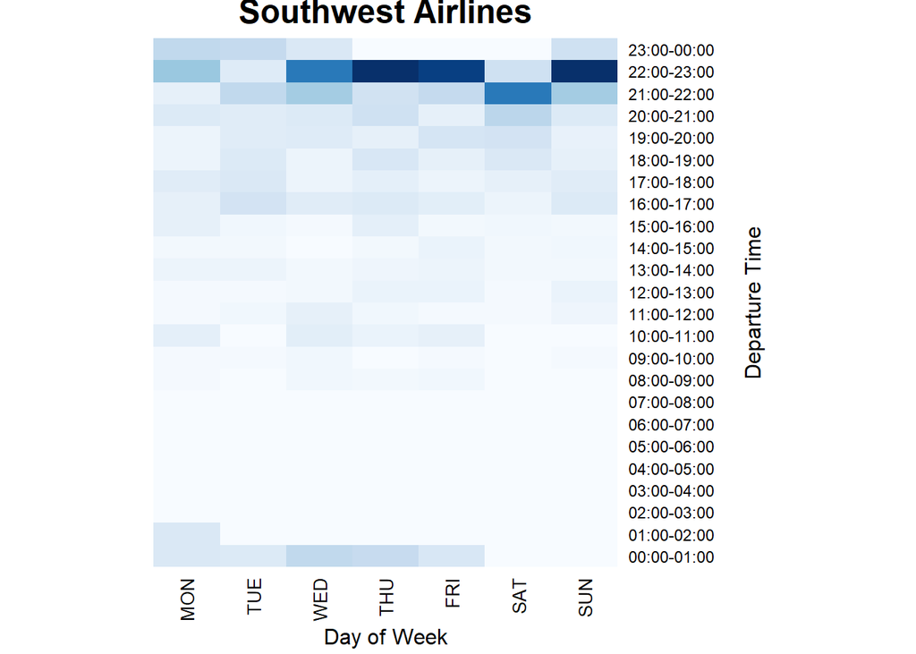

```r
#plot a heatmap for Southwest Airlines

heatmap(WN_m, Rowv=NA, Colv=NA,col= colorRampPalette(brewer.pal(9, "Blues"))(100),xlab="Day of Week", ylab="Departure Time", main="Southwest Airlines", scale = 'none', labCol = day, labRow = hour, margins = c(4,7), cexRow=0.9,cexCol = 1)
```

If you want to minimize delay, avoid Thursday, Friday, Sunday 22:00-23:00 flights from Southwest.

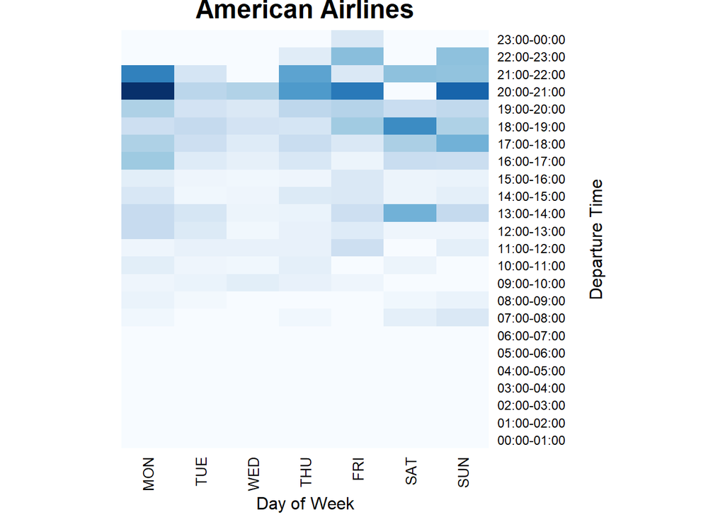

```r
#plot a heatmap for American Airlines

heatmap(AA_m, Rowv=NA, Colv=NA,col= colorRampPalette(brewer.pal(9, "Blues"))(100),xlab="Day of Week", ylab="Departure Time", main="American Airlines", scale = 'none', labCol = day, labRow = hour, margins = c(4,7), cexRow=0.9,cexCol = 1)
```

If you want to minimize delay, avoid Sunday and Monday 20:00 - 22:00 flights from American Airlines.

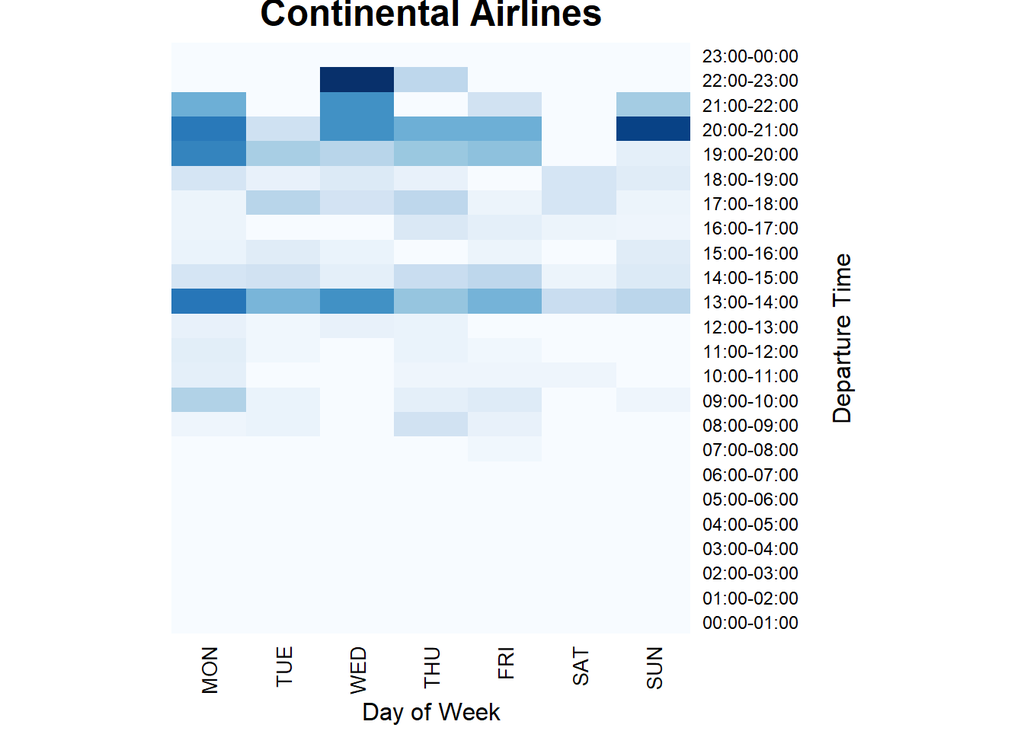

```r
#plot a heatmap for Continental Airlines

heatmap(CO_m, Rowv=NA, Colv=NA,col= colorRampPalette(brewer.pal(9, "Blues"))(100),xlab="Day of Week", ylab="Departure Time", main="Continental Airlines", scale = 'none', labCol = day, labRow = hour, margins = c(4,7), cexRow=0.9,cexCol = 1)
```

Try avoiding flights departing around 13:00-14:00 on Weekdays, as well as Monday, Wednesday, Sunday late night flights with Continental.

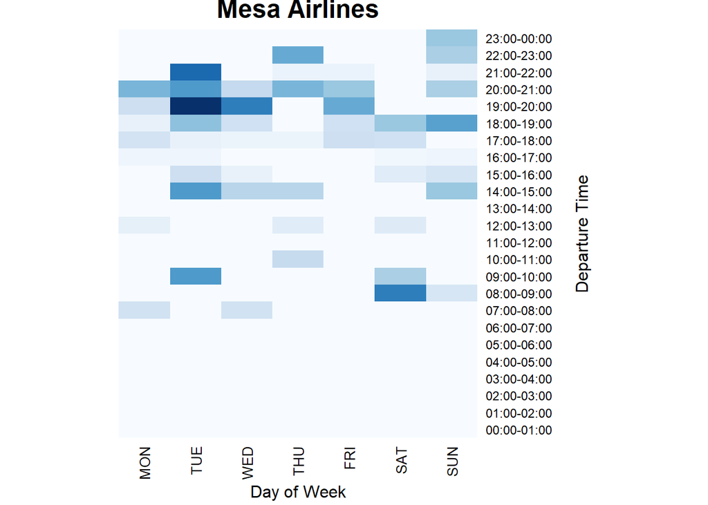

```r
#plot a heatmap for Mesa Airlines

heatmap(YV_m, Rowv=NA, Colv=NA,col= colorRampPalette(brewer.pal(9, "Blues"))(100),xlab="Day of Week", ylab="Departure Time", main="Mesa Airlines", scale = 'none', labCol = day, labRow = hour, margins = c(4,7), cexRow=0.9,cexCol = 1)
```

Mesa has several interesting delay blocks. In general, stay away from Mesa if you want to travel on a Tuesday night.

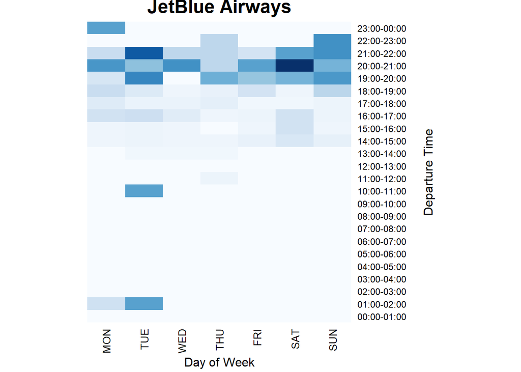

```r
#plot a heatmap for Jetblue Airlines

heatmap(B6_m, Rowv=NA, Colv=NA,col= colorRampPalette(brewer.pal(9, "Blues"))(100),xlab="Day of Week", ylab="Departure Time", main="JetBlue Airways", scale = 'none', labCol = day, labRow = hour, margins = c(4,7), cexRow=0.9,cexCol = 1)
```

If you want to minimize the possibility of delay, avoid Tuesday, Saturday, and Sunday 19:00-22:00 flights from Jetblue.

### Conclusion

With these heatmaps, travelers will be able to minimize delay time by choosing the best day-time combination with one of the top five airlines.

# Problem 2: Author attribution

### Setup

By function “text_data_preprocess” we get a cleaned Corpus containing all of 2500 the document wiritten by each author. And the “get_y” function gives us a length 2500 list of authors whose order is the same as our Corpus object.

```r
library(tm)
library(magrittr)
library(slam)
library(proxy)
library(glmnet)
library(caret)
library(dplyr)
library(naivebayes)
library(randomForest)
library(e1071)
library(caret)

text_data_preprocess = function(pp){
  writer_list = list.files(pp)

  read_f_list = c()


   readerPlain = function(fname){
    readPlain(elem=list(content=readLines(fname)),
              id=fname, language='en') }

  for ( i in writer_list){
    read_f_list = c(read_f_list,
                    Sys.glob(paste0(pp,i,'/*.txt')))
  }

  all_Doc = lapply(read_f_list, readerPlain)

  mynames = read_f_list %>%
  { strsplit(., '/', fixed=TRUE) } %>%
  { lapply(., tail, n=2) } %>%
  { lapply(., paste0, collapse = '') } %>%
    unlist


  names(all_Doc) = mynames



  documents_raw = Corpus(VectorSource(all_Doc))


  my_documents = documents_raw
  my_documents = tm_map(my_documents, content_transformer(tolower)) # make everything lowercase
  my_documents = tm_map(my_documents, content_transformer(removeNumbers)) # remove numbers
  my_documents = tm_map(my_documents, content_transformer(removePunctuation)) # remove punctuation
  my_documents = tm_map(my_documents, content_transformer(stripWhitespace)) ## remove excess white-space
  my_documents = tm_map(my_documents, content_transformer(removeWords), stopwords("en"))
  return(my_documents)
}

get_y = function(pp){
  writer_list = list.files(pp)
  y = c()
  for ( i in writer_list){
    y = c(y, rep(i,
                 times = length(list.files(paste0(pp,i)))))
  }
  return(y)
}
```

We build our “document term matrix” and prepare for PCA by removing sparse terms, sort columns by alphabetical order, and remove the zero-sum columns.

```r
my_documents = text_data_preprocess('C:/Users/Joseph/Desktop/jgscott git/data/ReutersC50/C50train/')
y = get_y('C:/Users/Joseph/Desktop/jgscott git/data/ReutersC50/C50train/')
DTM_all = DocumentTermMatrix(my_documents)
DTM_all_d = removeSparseTerms(DTM_all, 0.95)
DTM_all_s = DTM_all_d[ ,order(DTM_all_d$dimnames$Terms)]

tfidf_all = weightTfIdf(DTM_all_d)
tfidf_matrix = as.matrix(tfidf_all)

scrub_cols = which(colSums(tfidf_matrix) == 0)
pre_pca_1 = tfidf_matrix[,-scrub_cols]
```

We then read the test data, ordered it, and take the intersection of words used in both test data and training data.

```r
test_documents = text_data_preprocess('C:/Users/Joseph/Desktop/jgscott git/data/ReutersC50/C50test/')
y_test = get_y('C:/Users/Joseph/Desktop/jgscott git/data/ReutersC50/C50test/')
DTM_test = DocumentTermMatrix(test_documents)
DTM_test_s = DTM_test[, order(DTM_test$dimnames$Terms)]
Term_inter = intersect(Terms(DTM_test_s), colnames(pre_pca_1))
```

We then run PCA using our training document term matrix, using the vocabulary intersection as columns. And we tried to fit a logistic regression using first 100 prinicle component.

```r
pre_pca_2 = pre_pca_1[,Term_inter]
pc_doc = prcomp(pre_pca_2, scale = TRUE)
X = (pc_doc$x)[, 1:100]
logit_model = cv.glmnet(X,as.factor(y),family='multinomial',type.measure="class")
```

The last step is to predict y_test_hat using the lasso regression with the lambda having minimum error. We found that the accuracy of PCA + logistic regression is 55%

```r
DTM_test_c = DTM_test_s[,Term_inter]
tfidf_test = weightTfIdf(DTM_test_c)
tfidf_test_matrix = as.matrix(tfidf_test)
tfidf_test_matrix_s = scale(tfidf_test_matrix)
pc_test = (tfidf_test_matrix_s %*% pc_doc$rotation)[, 1:100]

y_test_hat = predict(logit_model,   pc_test,
                     type = "class", s = logit_model$lambda.min)
pred2   = ifelse( y_test_hat == y_test,  1, 0)
mean(pred2)
```

```
## [1] 0.5516
```

DarrenSchuettler,DavidLawder,EdnaFernandes,BenjaminKangLim,JaneMacartney,WilliamKazer are the authors that PCA + logistic regression can’t predict well.

```r
author_p_result_df = data.frame(y_test, pred2)
author_p_result= author_p_result_df %>%
    group_by(y_test) %>%
    summarise(p_accu = mean(X1))
author_p_result_s = author_p_result[order(author_p_result$p_accu),]
author_p_result_s[c(1:10),]
```

```
## # A tibble: 10 x 2
##    y_test           p_accu
##    <fct>             <dbl>
##  1 EdnaFernandes      0.16
##  2 DarrenSchuettler   0.18
##  3 DavidLawder        0.2
##  4 BenjaminKangLim    0.26
##  5 JaneMacartney      0.28
##  6 MureDickie         0.28
##  7 WilliamKazer       0.3
##  8 HeatherScoffield   0.32
##  9 MartinWolk         0.34
## 10 JanLopatka         0.38
```

### Naive Bayes

***Train/Test Set*

```r
mycorpus = text_data_preprocess('C:/Users/Joseph/Desktop/jgscott git/data/ReutersC50/C50train/')
labels = get_y('C:/Users/Joseph/Desktop/jgscott git/data/ReutersC50/C50train/')
DTM = DocumentTermMatrix(mycorpus)
DTM = removeSparseTerms(DTM, 0.975)
tfidf_train = weightTfIdf(DTM)

X = as.matrix(tfidf_train)

mycorpus2 = text_data_preprocess('C:/Users/Joseph/Desktop/jgscott git/data/ReutersC50/C50test/')
labels2 = get_y('C:/Users/Joseph/Desktop/jgscott git/data/ReutersC50/C50test/')

DTM2=DocumentTermMatrix(mycorpus2)
DTM2=removeSparseTerms(DTM2,0.975)
tfidf_test = weightTfIdf(DTM2)

x2=as.matrix(tfidf_test)


words=colnames(X)
words2=colnames(x2)

W=words[!(words %in% words2)]
W2=words2[!(words2 %in% words)]

words_matrix=matrix(0,nrow=nrow(x2), ncol=length(W))
colnames(words_matrix)=W

words_matrix2=matrix(0,nrow=nrow(X), ncol=length(W2))
colnames(words_matrix2)=W2

train_matrix=cbind(X,words_matrix2)
test_matrix=cbind(x2,words_matrix)
```

***Predict Test Accuracy*

```r
set.seed(1)
test_matrix=as.data.frame(test_matrix)
train_matrix=as.data.frame(train_matrix)

nb = naive_bayes(x=train_matrix,y=as.factor(labels),laplace=1)
predNB=predict(nb,test_matrix)

actual = rep(1:50,each=50)

TestTable = table(predNB,actual)
correct = 0
for (i in seq(1,50)){
    correct = correct + TestTable[i,i]
}

NB_accuracy = correct/2500
print(NB_accuracy)
```

```
## [1] 0.4412
```

***Confusion Matrix of Naive Bayes* First, creat a confusion matrix to calculate the accuracy of the model in predicting the authors. Sensitivity column gives the accuracy % of predicting the documents under each of the authors correctly. Also, the accuracy of the model is the average of the accuracy measures for all the authors.

```r
NB_confusion = confusionMatrix(table(predNB,labels))
NB_class= as.data.frame(NB_confusion$byClass)
NB_class[order(-NB_class$Sensitivity),][1]
```

```
##                          Sensitivity
## Class: LynnleyBrowning          0.84
## Class: MatthewBunce             0.74
## Class: RobinSidel               0.74
## Class: GrahamEarnshaw           0.68
## Class: BradDorfman              0.66
## Class: FumikoFujisaki           0.66
## Class: LynneO'Donnell           0.64
## Class: SarahDavison             0.64
## Class: NickLouth                0.62
## Class: LydiaZajc                0.60
## Class: SimonCowell              0.58
## Class: PeterHumphrey            0.56
## Class: JimGilchrist             0.54
## Class: KirstinRidley            0.54
## Class: AaronPressman            0.52
## Class: JoeOrtiz                 0.52
## Class: EricAuchard              0.50
## Class: TimFarrand               0.50
## Class: AlexanderSmith           0.48
## Class: JoWinterbottom           0.48
## Class: KeithWeir                0.48
## Class: JonathanBirt             0.46
## Class: PierreTran               0.46
## Class: MarcelMichelson          0.44
## Class: RogerFillion             0.44
## Class: BernardHickey            0.42
## Class: TheresePoletti           0.42
## Class: WilliamKazer             0.42
## Class: KarlPenhaul              0.40
## Class: SamuelPerry              0.40
## Class: HeatherScoffield         0.38
## Class: KevinDrawbaugh           0.38
## Class: TanEeLyn                 0.38
## Class: AlanCrosby               0.36
## Class: KevinMorrison            0.36
## Class: JohnMastrini             0.34
## Class: KouroshKarimkhany        0.34
## Class: MarkBendeich             0.34
## Class: MichaelConnor            0.32
## Class: MureDickie               0.32
## Class: JaneMacartney            0.30
## Class: MartinWolk               0.28
## Class: ScottHillis              0.28
## Class: ToddNissen               0.28
## Class: PatriciaCommins          0.22
## Class: JanLopatka               0.20
## Class: DavidLawder              0.16
## Class: EdnaFernandes            0.16
## Class: BenjaminKangLim          0.14
## Class: DarrenSchuettler         0.14
```

The model predict well for a few authors like LynnleyBrowning, MatthewBunce and RobinSidel. ###Random Forests### ***Predict Test Accuracy*

```r
set.seed(1)
RF = randomForest(y=as.factor(labels), x=train_matrix,ntrees=500)
pr = predict(RF, test_matrix, type = "response")

TestTable2 = table(pr, actual)

correct2 = 0
for (i in seq(1,50)){
    correct2 = correct2 + TestTable2[i,i]
}

RF_accuracy = correct2/2500
print(RF_accuracy)
```

```
## [1] 0.6188
```

**Confusion Matrix of Random Forest**

```r
RF_confusion = confusionMatrix(table(pr,labels))
RF_class= as.data.frame(RF_confusion$byClass)
RF_class[order(-RF_class$Sensitivity),][1]
##                          Sensitivity
## Class: FumikoFujisaki           1.00
## Class: JimGilchrist             0.98
## Class: LynnleyBrowning          0.98
## Class: GrahamEarnshaw           0.96
## Class: AaronPressman            0.94
## Class: KarlPenhaul              0.92
## Class: MatthewBunce             0.92
## Class: PeterHumphrey            0.90
## Class: JoWinterbottom           0.86
## Class: KouroshKarimkhany        0.86
## Class: NickLouth                0.86
## Class: RobinSidel               0.86
## Class: SimonCowell              0.84
## Class: MarcelMichelson          0.82
## Class: JohnMastrini             0.76
## Class: KeithWeir                0.76
## Class: LynneO'Donnell           0.76
## Class: MarkBendeich             0.76
## Class: MichaelConnor            0.76
## Class: RogerFillion             0.76
## Class: PatriciaCommins          0.74
## Class: TimFarrand               0.72
## Class: ToddNissen               0.72
## Class: BradDorfman              0.68
## Class: JonathanBirt             0.68
## Class: KevinDrawbaugh           0.64
## Class: SarahDavison             0.64
## Class: LydiaZajc                0.62
## Class: KevinMorrison            0.58
## Class: BernardHickey            0.52
## Class: JanLopatka               0.52
## Class: MureDickie               0.52
## Class: PierreTran               0.50
## Class: TheresePoletti           0.50
## Class: JoeOrtiz                 0.42
## Class: KirstinRidley            0.42
## Class: AlanCrosby               0.40
## Class: AlexanderSmith           0.40
## Class: HeatherScoffield         0.38
## Class: EricAuchard              0.36
## Class: JaneMacartney            0.34
## Class: SamuelPerry              0.34
## Class: TanEeLyn                 0.32
## Class: DarrenSchuettler         0.30
## Class: MartinWolk               0.30
## Class: WilliamKazer             0.30
## Class: BenjaminKangLim          0.28
## Class: EdnaFernandes            0.26
## Class: DavidLawder              0.14
## Class: ScottHillis              0.14
AccuracyRF = mean(RF_class$Sensitivity)
```

The model predict well for a few authors like FumikoFujisaki, JimGilchrist and LynnleyBrowning. And we can also see that random forest model, on average, have a better accuracy then the other model we did.

# Q3 Association Rule Mining

### Set up

```r
library(tidyverse)
library(arules)
library(arulesViz)
```

We first read in our grocery list by letting each row of the data as a basket of one shopping list.  
And we seperate each row by comma as items in each basket.

```r
groceries = read.transactions('C:/Users/Joseph/Desktop/jgscott git/data/groceries.txt',
                              format = 'basket',
                              sep = ',',
                              rm.duplicates = FALSE)
grocery<- as(groceries, "transactions")
```

The apriori algorithm is used to identify the associations between the different products from the different baskets that were loaded. We first choose a stricter criteria of support value = 0.005 and a confidence = 0.5 and we could observe that the results are mostly ‘whole milk’ and ‘other vegetables’.

Based on this result, we found that ‘whole milk’ and ‘other vegetables’ consists a significant portion of purchases from this grocery store. Therefore, we suggest that ‘whole milk’ and ‘other vegatables’ can be placed in the center of our store, which not only improves our costumor’s shopping experience by getting what they needed quickly but also increases exposure of other products.

```r
groc_rules <- apriori(grocery, parameter=list(support=.005, confidence=.5, maxlen=6))
```

```
## Apriori
##
## Parameter specification:
##  confidence minval smax arem  aval originalSupport maxtime support minlen
##         0.5    0.1    1 none FALSE            TRUE       5   0.005      1
##  maxlen target   ext
##       6  rules FALSE
##
## Algorithmic control:
##  filter tree heap memopt load sort verbose
##     0.1 TRUE TRUE  FALSE TRUE    2    TRUE
##
## Absolute minimum support count: 49
##
## set item appearances ...[0 item(s)] done [0.00s].
## set transactions ...[169 item(s), 9835 transaction(s)] done [0.01s].
## sorting and recoding items ... [120 item(s)] done [0.00s].
## creating transaction tree ... done [0.01s].
## checking subsets of size 1 2 3 4 done [0.00s].
## writing ... [120 rule(s)] done [0.00s].
## creating S4 object  ... done [0.00s].
```

```r
inspect(groc_rules)
```

```
##       lhs                           rhs                    support confidence     lift count
## [1]   {baking powder}            => {whole milk}       0.009252669  0.5229885 2.046793    91
## [2]   {oil,
##        other vegetables}         => {whole milk}       0.005083884  0.5102041 1.996760    50
## [3]   {onions,
##        root vegetables}          => {other vegetables} 0.005693950  0.6021505 3.112008    56
## [4]   {onions,
##        whole milk}               => {other vegetables} 0.006609049  0.5462185 2.822942    65
## [5]   {hygiene articles,
##        other vegetables}         => {whole milk}       0.005185562  0.5425532 2.123363    51
## [6]   {other vegetables,
##        sugar}                    => {whole milk}       0.006304016  0.5849057 2.289115    62
## [7]   {long life bakery product,
##        other vegetables}         => {whole milk}       0.005693950  0.5333333 2.087279    56
## [8]   {cream cheese,
##        yogurt}                   => {whole milk}       0.006609049  0.5327869 2.085141    65
## [9]   {chicken,
##        root vegetables}          => {other vegetables} 0.005693950  0.5233645 2.704829    56
## [10]  {chicken,
##        root vegetables}          => {whole milk}       0.005998983  0.5514019 2.157993    59
## [11]  {chicken,
##        rolls/buns}               => {whole milk}       0.005287239  0.5473684 2.142208    52
## [12]  {coffee,
##        yogurt}                   => {whole milk}       0.005083884  0.5208333 2.038359    50
## [13]  {frozen vegetables,
##        root vegetables}          => {other vegetables} 0.006100661  0.5263158 2.720082    60
## [14]  {frozen vegetables,
##        root vegetables}          => {whole milk}       0.006202339  0.5350877 2.094146    61
## [15]  {frozen vegetables,
##        rolls/buns}               => {whole milk}       0.005083884  0.5000000 1.956825    50
## [16]  {frozen vegetables,
##        other vegetables}         => {whole milk}       0.009659380  0.5428571 2.124552    95
## [17]  {beef,
##        yogurt}                   => {whole milk}       0.006100661  0.5217391 2.041904    60
## [18]  {beef,
##        rolls/buns}               => {whole milk}       0.006812405  0.5000000 1.956825    67
## [19]  {curd,
##        whipped/sour cream}       => {whole milk}       0.005897306  0.5631068 2.203802    58
## [20]  {curd,
##        tropical fruit}           => {yogurt}           0.005287239  0.5148515 3.690645    52
```

[output cut: 206 more lines]

```
## [116] {tropical fruit,
##        whole milk,
##        yogurt}                   => {other vegetables} 0.007625826  0.5033557 2.601421    75
## [117] {other vegetables,
##        root vegetables,
##        yogurt}                   => {whole milk}       0.007829181  0.6062992 2.372842    77
## [118] {root vegetables,
##        whole milk,
##        yogurt}                   => {other vegetables} 0.007829181  0.5384615 2.782853    77
## [119] {other vegetables,
##        rolls/buns,
##        root vegetables}          => {whole milk}       0.006202339  0.5083333 1.989438    61
## [120] {other vegetables,
##        rolls/buns,
##        yogurt}                   => {whole milk}       0.005998983  0.5221239 2.043410    59
```

### Set threshold for lift and confidence

In order to find other interesting associations on products that are puchased less, we loosen our filtering criteria to support = 0.002 and confidence = 0.4 and we sorted the association rules found by lift.

As we expected, items purchased less frequently are shown after adjusting our support filter. In addition, association rules found among them tend to have higher lift for their lower support.

```r
groc_rules_1 <- apriori(grocery, parameter=list(support=.002, confidence=.4, maxlen=6))
```

```
## Apriori
##
## Parameter specification:
##  confidence minval smax arem  aval originalSupport maxtime support minlen
##         0.4    0.1    1 none FALSE            TRUE       5   0.002      1
##  maxlen target   ext
##       6  rules FALSE
##
## Algorithmic control:
##  filter tree heap memopt load sort verbose
##     0.1 TRUE TRUE  FALSE TRUE    2    TRUE
##
## Absolute minimum support count: 19
##
## set item appearances ...[0 item(s)] done [0.00s].
## set transactions ...[169 item(s), 9835 transaction(s)] done [0.01s].
## sorting and recoding items ... [147 item(s)] done [0.00s].
## creating transaction tree ... done [0.00s].
## checking subsets of size 1 2 3 4 5 done [0.01s].
## writing ... [1914 rule(s)] done [0.00s].
## creating S4 object  ... done [0.00s].
```

```r
inspect(sort(subset(groc_rules_1, count >= 10, rhs), by = "lift")[c(1:50)])
```

```
##      lhs                        rhs                      support confidence     lift count
## [1]  {hard cheese,
##       whipped/sour cream}    => {butter}             0.002033554  0.4545455 8.202669    20
## [2]  {butter,
##       hard cheese}           => {whipped/sour cream} 0.002033554  0.5128205 7.154028    20
## [3]  {butter,
##       other vegetables,
##       tropical fruit}        => {whipped/sour cream} 0.002338587  0.4259259 5.941818    23
## [4]  {frozen vegetables,
##       other vegetables,
##       yogurt}                => {whipped/sour cream} 0.002236909  0.4230769 5.902073    22
## [5]  {beef,
##       citrus fruit,
##       other vegetables}      => {root vegetables}    0.002135231  0.6363636 5.838280    21
## [6]  {citrus fruit,
##       other vegetables,
##       tropical fruit,
##       whole milk}            => {root vegetables}    0.003152008  0.6326531 5.804238    31
## [7]  {citrus fruit,
##       frozen vegetables,
##       other vegetables}      => {root vegetables}    0.002033554  0.6250000 5.734025    20
## [8]  {beef,
##       other vegetables,
##       tropical fruit}        => {root vegetables}    0.002745297  0.6136364 5.629770    27
## [9]  {bottled water,
##       root vegetables,
##       yogurt}                => {tropical fruit}     0.002236909  0.5789474 5.517391    22
## [10] {herbs,
##       other vegetables,
##       whole milk}            => {root vegetables}    0.002440264  0.6000000 5.504664    24
## [11] {other vegetables,
##       root vegetables,
##       tropical fruit,
##       whole milk}            => {citrus fruit}       0.003152008  0.4492754 5.428284    31
## [12] {grapes,
##       pip fruit}             => {tropical fruit}     0.002135231  0.5675676 5.408941    21
## [13] {herbs,
##       yogurt}                => {root vegetables}    0.002033554  0.5714286 5.242537    20
## [14] {beef,
##       other vegetables,
```

[output cut: 95 more lines]

```
##       rolls/buns}            => {root vegetables}    0.002846975  0.4912281 4.506743    28
## [47] {citrus fruit,
##       fruit/vegetable juice,
##       other vegetables}      => {root vegetables}    0.002338587  0.4893617 4.489620    23
## [48] {citrus fruit,
##       other vegetables,
##       whole milk,
##       yogurt}                => {root vegetables}    0.002338587  0.4893617 4.489620    23
## [49] {hard cheese,
##       other vegetables,
##       whole milk}            => {root vegetables}    0.002135231  0.4883721 4.480541    21
## [50] {other vegetables,
##       rolls/buns,
##       tropical fruit,
##       whole milk}            => {yogurt}             0.002541942  0.6250000 4.480230    25
```

If we let support = 0.01 and confidence = 0.1 and observe the condition when lift > 3, we could see a clearer pattern of beef being bought along with root vegetables. This finding might help the marketing strategy of root vegetables since seller might not think of the fact that root vegetables are actually purchase a lot for side dishes when people want to have a steak or make beef stew.

```r
groc_rules_2 <- apriori(grocery, parameter=list(support=.01, confidence=.1, maxlen=6))
```

```
## Apriori
##
## Parameter specification:
##  confidence minval smax arem  aval originalSupport maxtime support minlen
##         0.1    0.1    1 none FALSE            TRUE       5    0.01      1
##  maxlen target   ext
##       6  rules FALSE
##
## Algorithmic control:
##  filter tree heap memopt load sort verbose
##     0.1 TRUE TRUE  FALSE TRUE    2    TRUE
##
## Absolute minimum support count: 98
##
## set item appearances ...[0 item(s)] done [0.00s].
## set transactions ...[169 item(s), 9835 transaction(s)] done [0.01s].
## sorting and recoding items ... [88 item(s)] done [0.00s].
## creating transaction tree ... done [0.00s].
## checking subsets of size 1 2 3 4 done [0.00s].
## writing ... [435 rule(s)] done [0.00s].
## creating S4 object  ... done [0.00s].
```

```r
inspect(subset(groc_rules_2, subset = lift > 3))
```

```
##     lhs                   rhs                     support confidence     lift count
## [1] {beef}             => {root vegetables}    0.01738688  0.3313953 3.040367   171
## [2] {root vegetables}  => {beef}               0.01738688  0.1595149 3.040367   171
## [3] {whole milk,
##      yogurt}           => {curd}               0.01006609  0.1796733 3.372304    99
## [4] {other vegetables,
##      yogurt}           => {whipped/sour cream} 0.01016777  0.2341920 3.267062   100
## [5] {citrus fruit,
##      root vegetables}  => {other vegetables}   0.01037112  0.5862069 3.029608   102
## [6] {citrus fruit,
##      other vegetables} => {root vegetables}    0.01037112  0.3591549 3.295045   102
## [7] {root vegetables,
##      tropical fruit}   => {other vegetables}   0.01230300  0.5845411 3.020999   121
## [8] {other vegetables,
##      tropical fruit}   => {root vegetables}    0.01230300  0.3427762 3.144780   121
```